# ForageModv02 sensitivity analysis

We assessed two aspects of the model to determine the best set of variables to use. First, we looked at how long to run each model for. Second, we look the effects of parameters that were not under investigation to determine the best values.

## Time

We explored how long to run the model for by testing how long it took the model to reach 100% burning probability for forager agents and how long it took the model to reach population equilibrium. We tested this at different values for the parameters that control burning costs and movement models, while holding all other parameters constant. We limited the model to 6000 ticks.

```
## $natural_ignition
## [1] 0
## Levels: 0
##
## $forager_moves
## [1] 10
## Levels: 10
##
## $veg_type_modifier
## [1] 200
## Levels: 200
##
## $forager_energy_requirement
## [1] 1500
## Levels: 1500
##
## $movement_cost
## [1] 100
## Levels: 100
##
## $reproduction_threshold
## [1] 5000
## Levels: 5000
##
## $reproduction_cost
## [1] 1000
## Levels: 1000
```

### How long to run the model?

```
##    Min. 1st Qu.  Median    Mean 3rd Qu.    Max.
##     558    3004    4230    4345    6000    6000
```

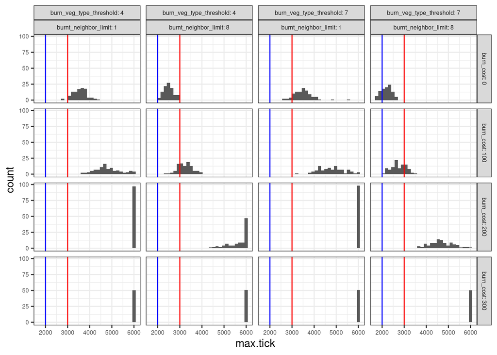

We can see that at the lowest restrictions and costs to burning behaviors, the model reaches 100% average probability of burning across all agents by approximately 2000 model ticks or 2000 foraging bouts (upper right facet). Imposing limits on burning increases the time to achieving a population with an average burning behavior probability of 100%.

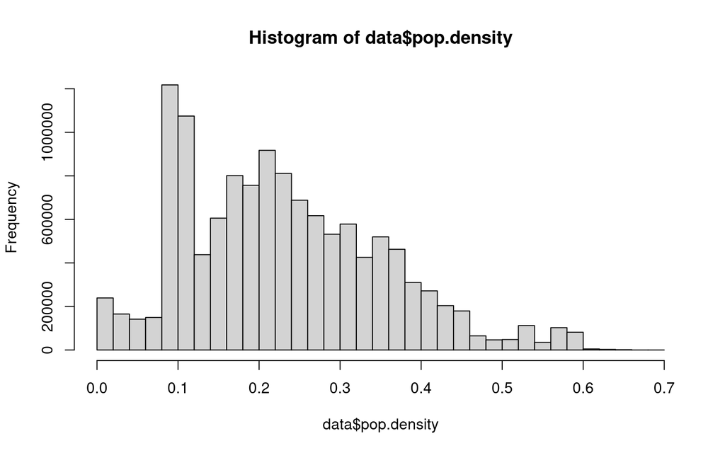

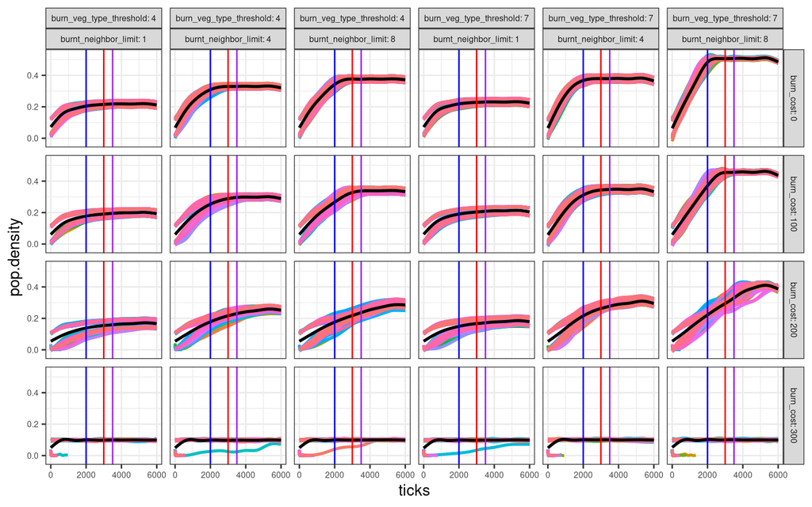

When looking at population growth over time, we see that unlimited burning allows populations to reach equilibrium quickly. More limited burning see slower population growth at the beginning of model run, allowing the population to grow more steadily. We can also see in this graph that different burning parameters create different population thresholds. This indicates that carrying capacity of the model is dictated by how many patches can be burned in a single time step.

## Parameters

We examined how forager burning probabilities and forager movement was affected by those parameters not studied in the paper. Specifically, we looked at varying the available energy in the environment (*veg-type-modifier*) and the thresholds/costs of non-disturbance forager behaviors. To do so, we allowed for essentially unlimited burning behaviors by holding *burn-cost*, *burnt-neighbor-limit*, and *burn-veg-type-threshold* constant. We also tested with one type of environmental scenario - starting in a productive environment and cycling the environment every 100 ticks - and one type of movement model - random walking. We tested the effects of the parameters listed below at a low, medium, and high value.

```
## $natural_ignition
## [1] 0   0.5
## Levels: 0 0.5
##
## $forager_moves
## [1] 10 15 5
## Levels: 5 10 15
##
## $veg_type_modifier
## [1] 200 300 100
## Levels: 100 200 300
##
## $forager_energy_requirement
## [1] 1000 2000 1500
## Levels: 1000 1500 2000
##
## $movement_cost
## [1] 150 50  100
## Levels: 50 100 150
##
## $reproduction_threshold
## [1] 4000 6000 5000
## Levels: 4000 5000 6000
##
## $reproduction_cost
## [1] 500  1000 1500
## Levels: 500 1000 1500
```

### What parameters result in population dying off?

```r
all.exp = unique(data$exp)

end.tick = unique(data$`tick-limit`)
fd = data %>% filter(ticks == end.tick)
finished.exp = unique(fd$exp)

finished.data = data %>% filter(exp %in% finished.exp)
unfinished.data = data %>% filter(!(exp %in% finished.exp))
length(unique(unfinished.data$exp)) / length(unique(data$exp))
```

```
## [1] 0.5069959
```

Over half of the model runs performed in the sensitivity analysis do not sustain a population to the end of model run (ticks = 500).

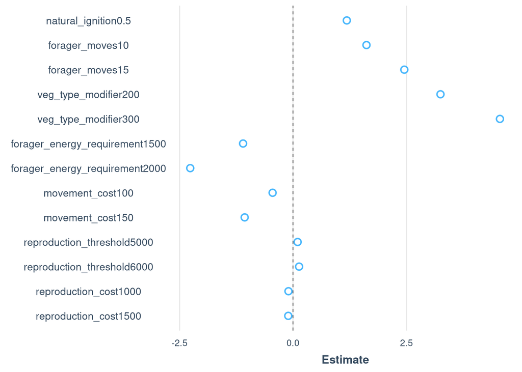

```r
max.ticks = unfinished.data %>% group_by_at(c("exp", parameters)) %>%
  summarize(max.tick = max(ticks))

#lapply(max.ticks[,c(reg.parameters)], summary)

plot_summs(glm(max.tick ~ ., data = max.ticks[,c("max.tick", reg.parameters)], family = "poisson"), scale = T)
```

By running a Poisson regression on the maximum number of ticks the model reaches when the populations die off, we can see that survival is primarily controlled by forager energy requirements, forager movement/movement costs, and resource availability (*veg_type_modifier*).

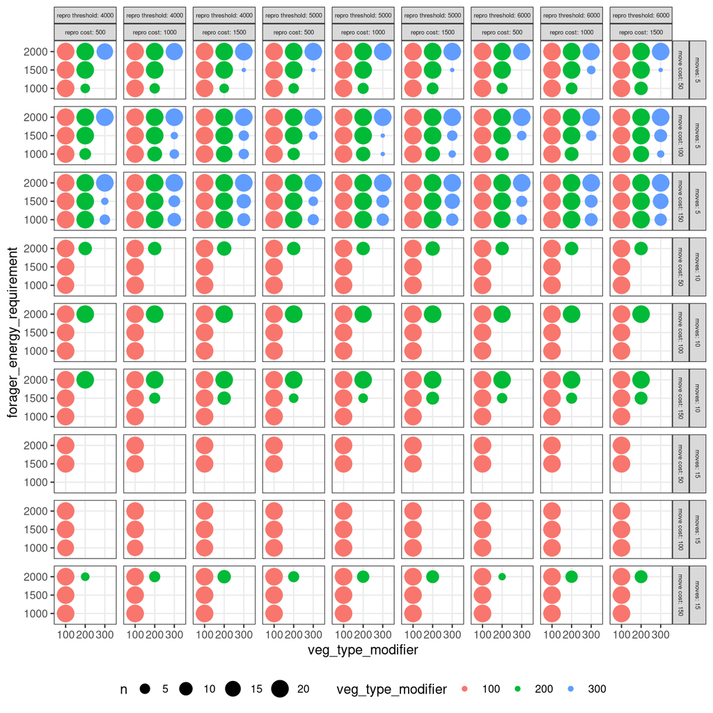

The above count graph shows those model runs that do not sustain a population until the end of model run. We can clearly see that limited forager mobility (*forager-moves* = 5) and high movement cost (*movement-cost* = 150), low resource availability (*veg-type-modifier* = 100), and high cost of foraging (*forager-energy-requirement* = 2000) result in population extinction. High reproduction costs and thresholds also can lead to populations dying off before the end of model run. For the final experiments, we chose parameters that allow for populations to frequently be sustained until the end of model run.

### When population is maintained, how do the parameters affect this?

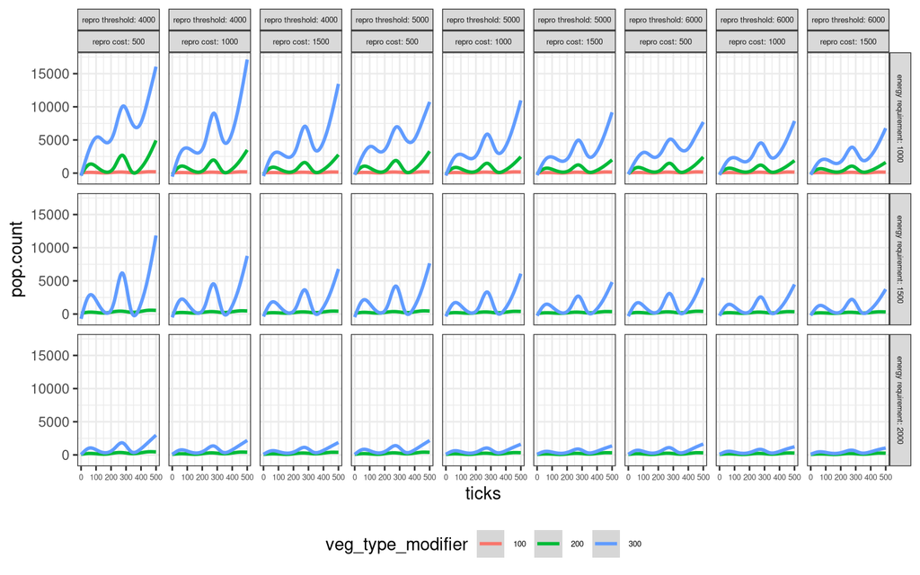

Access to energy is a critical determinant of population survival and population size. High amounts of energy in the environment (*veg_type_modifier* = 300) and low forager/reproduction costs (top left graphs) result in very large populations, which in turn have high computing requirements for the model. For this reason, we intentionally chose some values for the final experiments that keep the population smaller.

### How do the parameters affect burning probabilities?

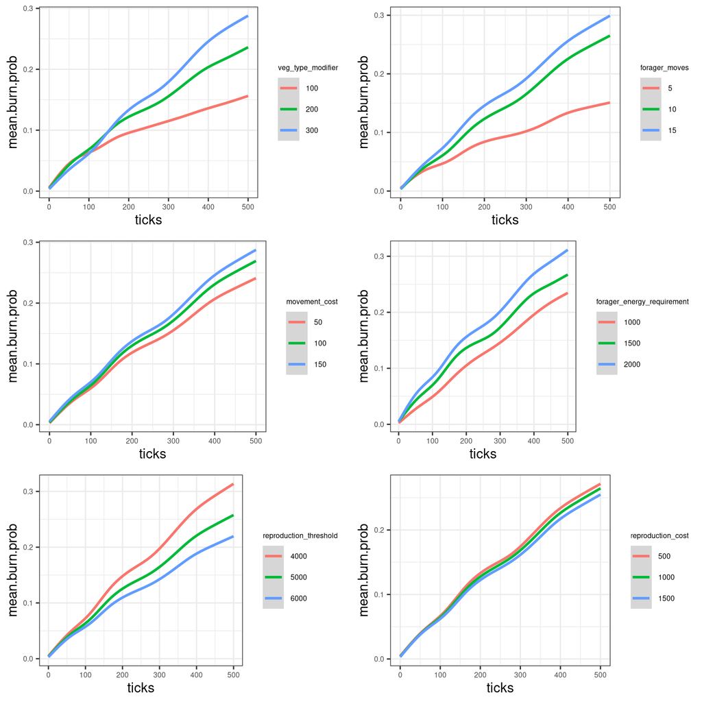

Across all parameters, burning probability increases. We look at the final average burning probability to compare parameter effects. Specifically, we test for significant differences in resulting burning probabilities using Mann-Whitney (two-sample Wilcoxon) tests. For all tests, we look at the differences separated out by foraging costs (*forager-energy-requirement*) and energy required for reproduction (*reproduction-threshold*).

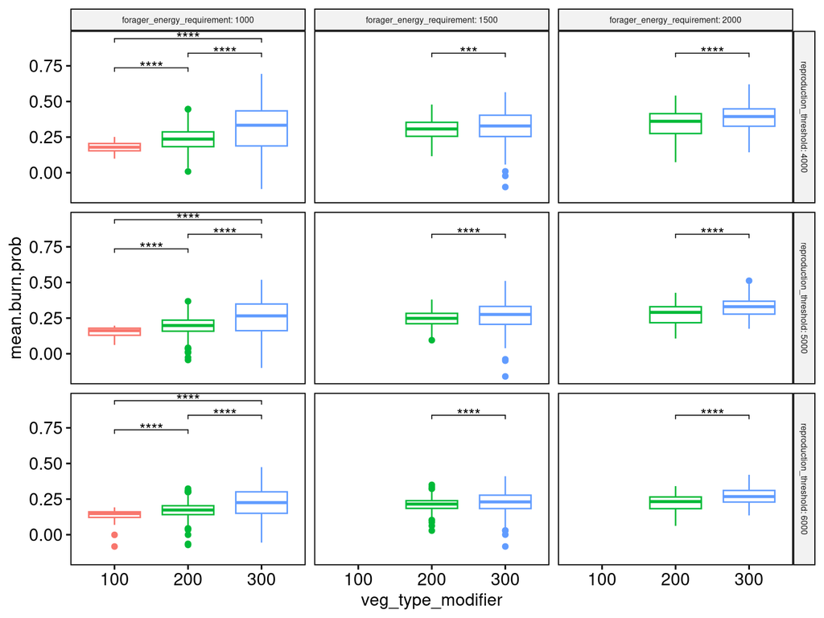

First, what is obvious is that with high enough forager energy requirements, there need to be enough resources available (*veg-type-modifier*) in the environment for populations to survive. With low forager energy requirements, the differences introduced by changes in *veg-type-modifier* are larger. When forager energy requirements are higher, these differences, while still significant, are not as large, particularly at lower reproduction thresholds. For this reason, we preferred middle values of *forager-energy-requirement*, *reproduction-threshold*, and *veg-type-modifier* for the final experiments.

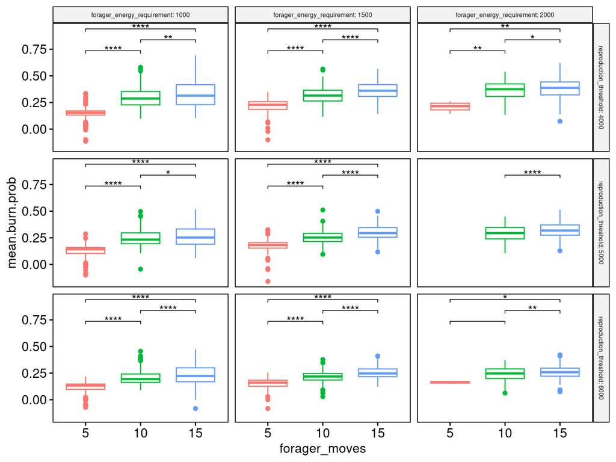

An alternative population maintenance strategy to enough energy availability in the environment is that agents must be able to move more to access more resources (*forager-moves*). Again, here we see smaller significant differences in final burning probability between the middle and high value of *forager-moves* across all energy requirements/thresholds.

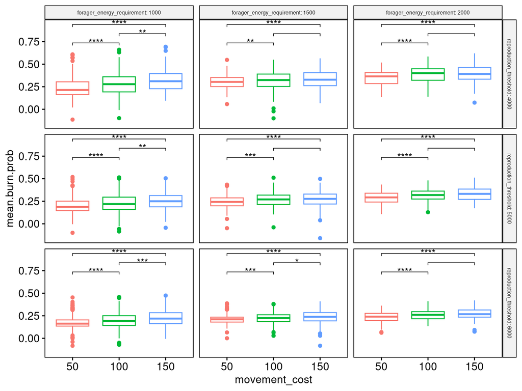

The cost of movement (*movement-cost*) will play a role in how many patches a forager can access and/or burn during a foraging bout. We can see that the middle and high values for *movement-cost* allow for similar evolution of burning behaviors by the end of model run. It is only when foraging energy requirements are low, allowing for larger populations, that we see significant differences produced by different movement costs.

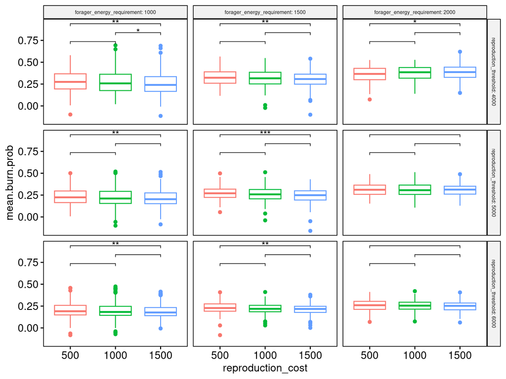

Changes in reproduction costs produce some significant differences, but these are not consistent across energy requirements/thresholds.

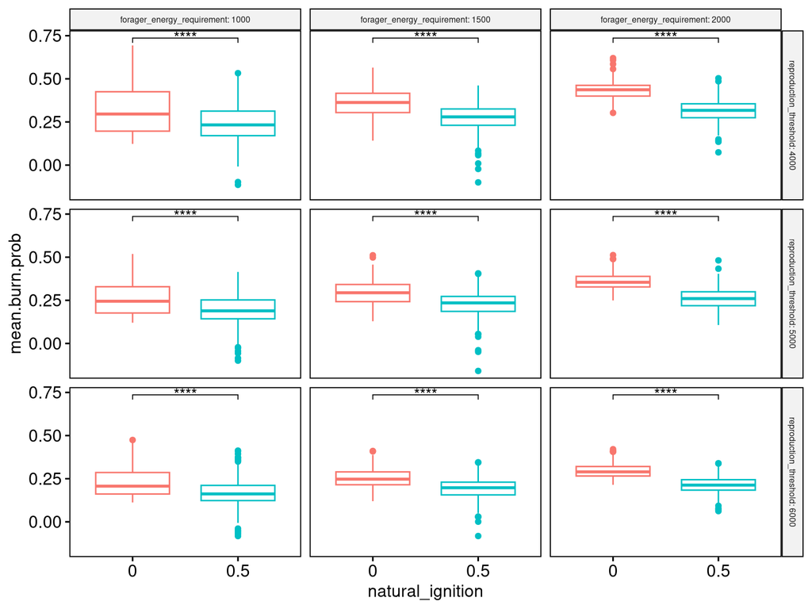

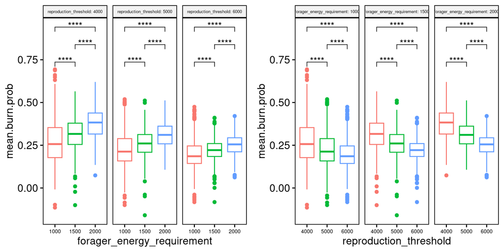

Finally, when comparing across different values for forager energy requirements or reproduction threshold, we see significant differences. Final burning probability increases with higher energy requirements and decreases with higher reproduction thresholds.

While altering these parameters do change the rate of increase of burning probabilities in the model, all parameter settings result in increasing burning probabilities, meaning that final result of the model will always be the same: 100% burning probability. This means that choosing the parameters for the final experiments could take into consideration other factors beside their effect on burning probability.

### How do the parameters affect forager movement?

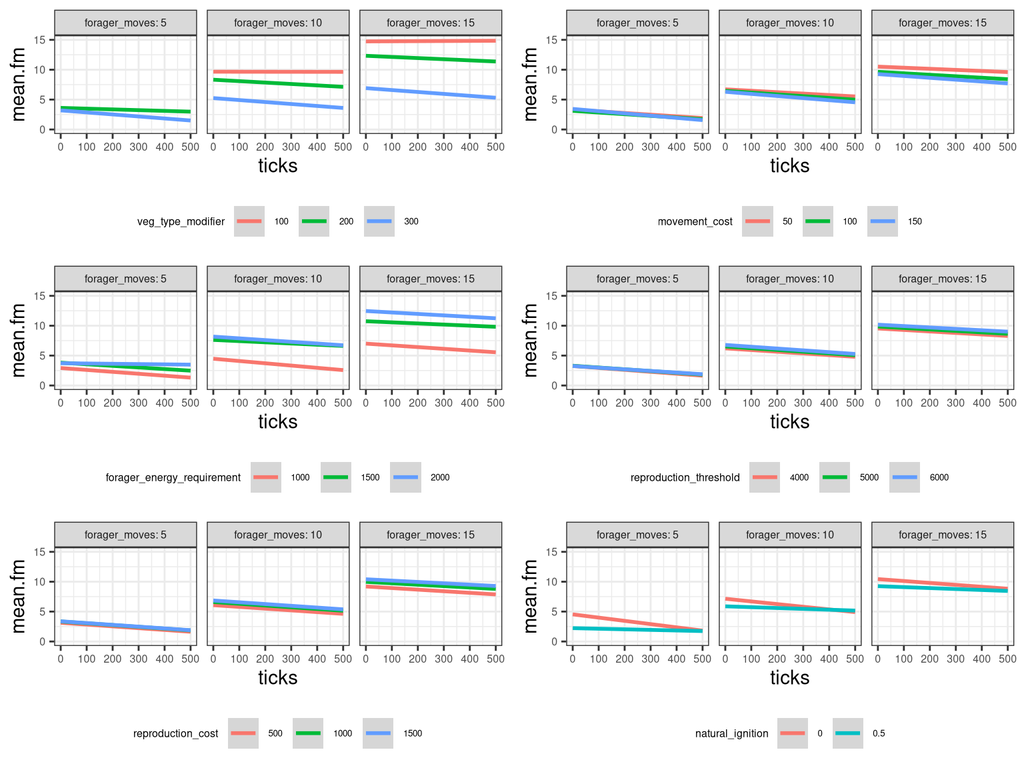

It is clear that the reproduction parameters do not have a large effect on forager movement compared to the parameters that control resource availability (*veg-type-modifier*) and foraging costs (*forager-energy-requirement*). Aside from showing what we already know (that foragers must be able to perform a high enough number of steps per foraging bouts when foraging costs are higher and resource availability is limited), the above results demonstrate that differences caused by the other parameters are minimized with lower forager movement. However, since forager movement needs to be high enough to maintain the population, we chose the middle value for the final experiments.

### How do the parameters affect proportion of vegetation types across the landscape?

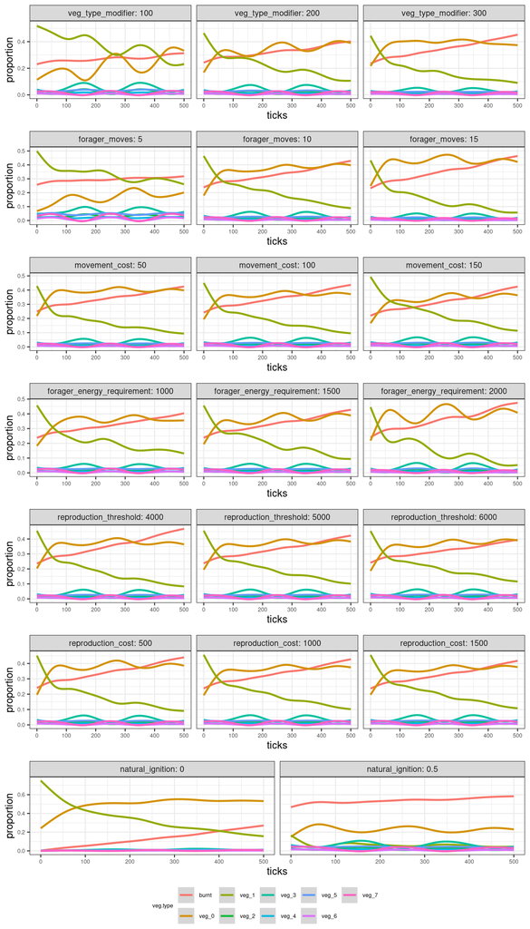

Across the parameters tested here, the relationships between the proportions of different vegetation types on the landscape remain relatively the same. The main effect is on *veg_0* which represents proportion of the landscape with foraged patches. This changes slightly as forager ability to access different parts of the landscape is altered by movement costs and maximum number of moves per foraging bout.

Otherwise, the main trend is low levels of vegetation types greater than 1 (which is the starting value for all patches) and a slow decline in the proportion of vegetation type 1 as more of the landscape gets burnt each time step and turns over into higher vegetation types.

Given these results, any of the values used would produce a similar pattern of vegetation types. This supports our use of the middle values tested.

## Conclusion

For all of the reasons outlined in the above sensitivity analysis, we use the middle values of each of the parameters tested here for the final experiments. These are:

## References

| Package | Version | Citation |
| --- | --- | --- |
| base | 4.3.2 | (1) |
| betareg | 3.1.4 | (2); (3) |
| corrplot | 0.92 | (4) |
| fitdistrplus | 1.2.1 | (5) |
| formatR | 1.14 | (6) |
| ggeffects | 1.7.0 | (7) |
| ggpubr | 0.6.0 | (8) |
| ggsignif | 0.6.4 | (9) |
| ggspatial | 1.1.9 | (10) |
| ggthemes | 5.1.0 | (11) |
| grateful | 0.2.10 | (12) |
| grid | 4.3.2 | (13) |
| gtsummary | 1.7.2 | (14) |
| jtools | 2.2.2 | (15) |
| knitr | 1.45 | (16); (17); (18) |
| lme4 | 1.1.35.1 | (19) |
| lmerTest | 3.1.3 | (20) |
| mgcv | 1.9.1 | (21); (22); (23); (24); (25) |
| png | 0.1.8 | (26) |
| psych | 2.3.9 | (27) |
| rcompanion | 2.4.36 | (28) |
| rmarkdown | 2.25 | (29); (30); (31) |
| scales | 1.3.0 | (32) |
| segmented | 2.0.0 | (33); (34); (35); (36); (37); (38) |
| sp | 2.1.4 | (39); (40) |
| spdep | 1.3.5 | (41); (42); (43); (44) |
| tidyverse | 2.0.0 | (45) |
| vegan | 2.6.6.1 | (46) |

1.

R Core Team, *[R: A language and environment for statistical computing](https://www.R-project.org/)* (R Foundation for Statistical Computing, 2023).

2.

F. Cribari-Neto, A. Zeileis, [Beta regression in R](https://doi.org/10.18637/jss.v034.i02). *Journal of Statistical Software* **34**, 1–24 (2010).

3.

B. Grün, I. Kosmidis, A. Zeileis, [Extended beta regression in R: Shaken, stirred, mixed, and partitioned](https://doi.org/10.18637/jss.v048.i11). *Journal of Statistical Software* **48**, 1–25 (2012).

4.

T. Wei, V. Simko, *[R package “corrplot”: Visualization of a correlation matrix](https://github.com/taiyun/corrplot)* (2021).

5.

M. L. Delignette-Muller, C. Dutang, [fitdistrplus: An R package for fitting distributions](https://doi.org/10.18637/jss.v064.i04). *Journal of Statistical Software* **64**, 1–34 (2015).

6.

Y. Xie, *[formatR: Format r code automatically](https://CRAN.R-project.org/package=formatR)* (2023).

7.

D. Lüdecke, [ggeffects: Tidy data frames of marginal effects from regression models.](https://doi.org/10.21105/joss.00772) *Journal of Open Source Software* **3**, 772 (2018).

8.

A. Kassambara, *[ggpubr: “ggplot2” based publication ready plots](https://CRAN.R-project.org/package=ggpubr)* (2023).

9.

A.-E. Constantin, I. Patil, ggsignif: R package for displaying significance brackets for “ggplot2”. *PsyArxiv* (2021). https://doi.org/10.31234/osf.io/7awm6.

10.

D. Dunnington, *[ggspatial: Spatial data framework for ggplot2](https://CRAN.R-project.org/package=ggspatial)* (2023).

11.

J. B. Arnold, *[ggthemes: Extra themes, scales and geoms for “ggplot2”](https://CRAN.R-project.org/package=ggthemes)* (2024).

12.

F. Rodriguez-Sanchez, C. P. Jackson, *[grateful: Facilitate citation of r packages](https://pakillo.github.io/grateful/)* (2023).

13.

R Core Team, *[R: A language and environment for statistical computing](https://www.R-project.org/)* (R Foundation for Statistical Computing, 2023).

14.

D. D. Sjoberg, K. Whiting, M. Curry, J. A. Lavery, J. Larmarange, [Reproducible summary tables with the gtsummary package](https://doi.org/10.32614/RJ-2021-053). *The R Journal* **13**, 570–580 (2021).

15.

J. A. Long, *[jtools: Analysis and presentation of social scientific data](https://cran.r-project.org/package=jtools)* (2022).

16.

Y. Xie, “knitr: A comprehensive tool for reproducible research in R” in *Implementing Reproducible Computational Research*, V. Stodden, F. Leisch, R. D. Peng, Eds. (Chapman; Hall/CRC, 2014).

17.

Y. Xie, *[Dynamic documents with R and knitr](https://yihui.org/knitr/)*, 2nd Ed. (Chapman; Hall/CRC, 2015).

18.

Y. Xie, *[knitr: A general-purpose package for dynamic report generation in r](https://yihui.org/knitr/)* (2023).

19.

D. Bates, M. Mächler, B. Bolker, S. Walker, [Fitting linear mixed-effects models using lme4](https://doi.org/10.18637/jss.v067.i01). *Journal of Statistical Software* **67**, 1–48 (2015).

20.

A. Kuznetsova, P. B. Brockhoff, R. H. B. Christensen, [lmerTest package: Tests in linear mixed effects models](https://doi.org/10.18637/jss.v082.i13). *Journal of Statistical Software* **82**, 1–26 (2017).

21.

S. N. Wood, Thin-plate regression splines. *Journal of the Royal Statistical Society (B)* **65**, 95–114 (2003).

22.

S. N. Wood, Stable and efficient multiple smoothing parameter estimation for generalized additive models. *Journal of the American Statistical Association* **99**, 673–686 (2004).

23.

S. N. Wood, Fast stable restricted maximum likelihood and marginal likelihood estimation of semiparametric generalized linear models. *Journal of the Royal Statistical Society (B)* **73**, 3–36 (2011).

24.

S. N. Wood, N., Pya, B. S"afken, Smoothing parameter and model selection for general smooth models (with discussion). *Journal of the American Statistical Association* **111**, 1548–1575 (2016).

25.

S. N. Wood, *Generalized additive models: An introduction with r*, 2nd Ed. (Chapman; Hall/CRC, 2017).

26.

S. Urbanek, *[png: Read and write PNG images](https://CRAN.R-project.org/package=png)* (2022).

27.

William Revelle, *[psych: Procedures for psychological, psychometric, and personality research](https://CRAN.R-project.org/package=psych)* (Northwestern University, 2023).

28.

S. S. Mangiafico, *[rcompanion: Functions to support extension education program evaluation](https://CRAN.R-project.org/package=rcompanion/)* (Rutgers Cooperative Extension, 2024).

29.

Y. Xie, J. J. Allaire, G. Grolemund, *[R markdown: The definitive guide](https://bookdown.org/yihui/rmarkdown)* (Chapman; Hall/CRC, 2018).

30.

Y. Xie, C. Dervieux, E. Riederer, *[R markdown cookbook](https://bookdown.org/yihui/rmarkdown-cookbook)* (Chapman; Hall/CRC, 2020).

31.

J. Allaire, *et al.*, *[rmarkdown: Dynamic documents for r](https://github.com/rstudio/rmarkdown)* (2023).

32.

H. Wickham, T. L. Pedersen, D. Seidel, *[scales: Scale functions for visualization](https://CRAN.R-project.org/package=scales)* (2023).

33.

V. M. R. Muggeo, Estimating regression models with unknown break-points. *Statistics in Medicine* **22**, 3055–3071 (2003).

34.

V. M. R. Muggeo, [segmented: An r package to fit regression models with broken-line relationships.](https://cran.r-project.org/doc/Rnews/) *R News* **8**, 20–25 (2008).

35.

V. M. R. Muggeo, D. C. Atkins, R. J. Gallop, S. Dimidjian, Segmented mixed models with random changepoints: A maximum likelihood approach with application to treatment for depression study. *Statistical Modelling* **14**, 293–313 (2014).

36.

V. M. R. Muggeo, Testing with a nuisance parameter present only under the alternative: A score-based approach with application to segmented modelling. *J of Statistical Computation and Simulation* **86**, 3059–3067 (2016).

37.

V. M. R. Muggeo, Interval estimation for the breakpoint in segmented regression: A smoothed score-based approach. *Australian & New Zealand Journal of Statistics* **59**, 311–322 (2017).

38.

S. Fasola, V. M. R. Muggeo, H. Kuchenhoff, A heuristic, iterative algorithm for change-point detection in abrupt change models. *Computational Statistics* **33**, 997–1015 (2018).

39.

E. J. Pebesma, R. Bivand, [Classes and methods for spatial data in R](https://CRAN.R-project.org/doc/Rnews/). *R News* **5**, 9–13 (2005).

40.

R. S. Bivand, E. Pebesma, V. Gomez-Rubio, *[Applied spatial data analysis with R, second edition](https://asdar-book.org/)* (Springer, NY, 2013).

41.

R. S. Bivand, E. Pebesma, V. Gómez-Rubio, *[Applied spatial data analysis with R, second edition](https://asdar-book.org/)* (Springer, NY, 2013).

42.

R. Bivand, D. W. S. Wong, [Comparing implementations of global and local indicators of spatial association](https://doi.org/10.1007/s11749-018-0599-x). *TEST* **27**, 716–748 (2018).

43.

Roger Bivand, [R packages for analyzing spatial data: A comparative case study with areal data](https://doi.org/10.1111/gean.12319). *Geographical Analysis* **54**, 488–518 (2022).

44.

E. Pebesma, R. S. Bivand, *[Spatial data science with applications in R](https://r-spatial.org/book/)* (Chapman & Hall, 2023).

45.

H. Wickham, *et al.*, [Welcome to the tidyverse](https://doi.org/10.21105/joss.01686). *Journal of Open Source Software* **4**, 1686 (2019).

46.

J. Oksanen, *et al.*, *[vegan: Community ecology package](https://CRAN.R-project.org/package=vegan)* (2024).